# Build and train model

## Skeleton Code

The code below provides a skeleton for the model building & training component of your project. You can add/remove/build on code however you see fit, this is meant as a starting point.

```python
import numpy as np # linear algebra
import pandas as pd # data processing, CSV file I/O (e.g. pd.read_csv)
import os
from glob import glob
%matplotlib inline
import matplotlib.pyplot as plt
from itertools import chain

import sklearn.model_selection as skl
from random import sample
from keras.preprocessing.image import ImageDataGenerator

from keras.preprocessing.image import ImageDataGenerator
from keras.layers import GlobalAveragePooling2D, Dense, Dropout, Flatten, Conv2D, MaxPooling2D
from keras.models import Sequential, Model
from keras.applications.vgg16 import VGG16
from keras.applications.resnet import ResNet50
from keras.optimizers import Adam
from keras.callbacks import ModelCheckpoint, LearningRateScheduler, EarlyStopping, ReduceLROnPlateau
from keras.layers import LeakyReLU
```

## Do some early processing of your metadata for easier model training:

```python
## Below is some helper code to read all of your full image filepaths into a dataframe for easier manipulation

all_xray_df = pd.read_csv('/data/Data_Entry_2017.csv')
all_image_paths = {os.path.basename(x): x for x in
                   glob(os.path.join('/data','images*', '*', '*.png'))}
print('Scans found:', len(all_image_paths), ', Total Headers', all_xray_df.shape[0])
all_xray_df['path'] = all_xray_df['Image Index'].map(all_image_paths.get)
all_xray_df.sample(3)
```

```
Scans found: 112120 , Total Headers 112120
```

|  | Image Index | Finding Labels | Follow-up # | Patient ID | Patient Age | Patient Gender | View Position | OriginalImage[Width | Height] | OriginalImagePixelSpacing[x | y] | Unnamed: 11 | path |
| --- | --- | --- | --- | --- | --- | --- | --- | --- | --- | --- | --- | --- | --- |
| 72963 | 00017980_003.png | No Finding | 3 | 17980 | 19 | M | AP | 2500 | 2048 | 0.168 | 0.168 | NaN | /data/images_008/images/00017980_003.png |
| 56319 | 00014022_050.png | Fibrosis | 50 | 14022 | 66 | M | AP | 2048 | 2500 | 0.168 | 0.168 | NaN | /data/images_007/images/00014022_050.png |
| 65426 | 00016150_002.png | No Finding | 2 | 16150 | 46 | M | AP | 2500 | 2048 | 0.168 | 0.168 | NaN | /data/images_008/images/00016150_002.png |

```python
## Here you may want to create some extra columns in your table with binary indicators of certain diseases
## rather than working directly with the 'Finding Labels' column
d = all_xray_df.copy()
all_labels = np.unique(list(chain(*d['Finding Labels'].map(lambda x: x.split('|')).tolist())))
all_labels = [x for x in all_labels if len(x)>0]
print('All Labels ({}): {}'.format(len(all_labels), all_labels))
for c_label in all_labels:
    if len(c_label)>1: # leave out empty labels
        d[c_label] = d['Finding Labels'].map(lambda finding: 1.0 if c_label in finding else 0)
# Todo
```

```
All Labels (15): ['Atelectasis', 'Cardiomegaly', 'Consolidation', 'Edema', 'Effusion', 'Emphysema', 'Fibrosis', 'Hernia', 'Infiltration', 'Mass', 'No Finding', 'Nodule', 'Pleural_Thickening', 'Pneumonia', 'Pneumothorax']
```

```python
## Here we can create a new column called 'pneumonia_class' that will allow us to look at
## images with or without pneumonia for binary classification
d.Pneumonia = d.Pneumonia.replace(0.0, "No")
d.Pneumonia = d.Pneumonia.replace(1.0, "Yes")

#d = d.rename(columns={'Pneumonia': 'pneumonia_class'})
```

```python
d = d.rename(columns={'Pneumonia': 'pneumonia_class'})
```

## Create your training and testing data:

```python
def create_splits(vargs):

    ## Either build your own or use a built-in library to split your original dataframe into two sets
    ## that can be used for training and testing your model
    ## It's important to consider here how balanced or imbalanced you want each of those sets to be
    ## for the presence of pneumonia

    # Todo


    train_data, val_data = skl.train_test_split(vargs,
                                       test_size = 0.2,
                                       stratify = vargs['pneumonia_class'])

    p_inds = train_data[train_data.pneumonia_class=='Yes'].index.tolist()
    np_inds = train_data[train_data.pneumonia_class=='No'].index.tolist()

    np_sample = sample(np_inds,len(p_inds))
    train_df = train_data.loc[p_inds + np_sample]


    p_inds = val_data[val_data.pneumonia_class=='Yes'].index.tolist()
    np_inds = val_data[val_data.pneumonia_class=='No'].index.tolist()

    np_sample = sample(np_inds,4*len(p_inds))
    valid_df = val_data.loc[p_inds + np_sample]

    #print(train_df.head(1))
    return train_df, valid_df
```

```python
train_df, val_df = create_splits(d)
```

# Now we can begin our model-building & training

#### First suggestion: perform some image augmentation on your data

```python
def my_image_augmentation(vargs):

    ## recommendation here to implement a package like Keras' ImageDataGenerator
    ## with some of the built-in augmentations

    ## keep an eye out for types of augmentation that are or are not appropriate for medical imaging data
    ## Also keep in mind what sort of augmentation is or is not appropriate for testing vs validation data

    ## STAND-OUT SUGGESTION: implement some of your own custom augmentation that's *not*
    ## built into something like a Keras package

    # Todo
    if vargs == 'train':
        my_idg = ImageDataGenerator(rescale=1. / 255.0,
                                  horizontal_flip = True,
                                  vertical_flip = False,
                                  height_shift_range= 0.1,
                                  width_shift_range=0.1,
                                  rotation_range=20,
                                  shear_range = 0.1,
                                  zoom_range=0.25)
    elif vargs == 'valid':
        my_idg = ImageDataGenerator(rescale=1. / 255.0,
                                  horizontal_flip = False,
                                  vertical_flip = False)

    return my_idg


def make_train_gen(vargs):

    ## Create the actual generators using the output of my_image_augmentation for your training data
    ## Suggestion here to use the flow_from_dataframe library, e.g.:

#     train_gen = my_train_idg.flow_from_dataframe(dataframe=train_df,
#                                          directory=None,
#                                          x_col = ,
#                                          y_col = ,
#                                          class_mode = 'binary',
#                                          target_size = ,
#                                          batch_size =
#                                          )
     # Todo
    my_train_idg = my_image_augmentation('train')
    IMG_SIZE = (224, 224) ###VGG takes in 224x224 images

    df = vargs
    train_gen = my_train_idg.flow_from_dataframe(dataframe=df,
                                         directory=None,
                                         x_col = 'path',
                                         y_col = 'pneumonia_class',
                                         class_mode = 'binary',
                                         target_size = IMG_SIZE,
                                         batch_size = 32
                                         )

    return train_gen


def make_val_gen(vargs):

#     val_gen = my_val_idg.flow_from_dataframe(dataframe = val_data,
#                                              directory=None,
#                                              x_col = ,
#                                              y_col = ',
#                                              class_mode = 'binary',
#                                              target_size = ,
#                                              batch_size = )
    my_val_idg = my_image_augmentation('valid')
    IMG_SIZE = (224, 224) ###VGG takes in 224x224 images

    df = vargs
    val_gen = my_val_idg.flow_from_dataframe(dataframe=df,
                                         directory=None,
                                         x_col = 'path',
                                         y_col = 'pneumonia_class',
                                         class_mode = 'binary',
                                         target_size = IMG_SIZE,
                                         batch_size = 32
                                         )


    return val_gen

train_gen = make_train_gen(train_df)
val_gen   = make_val_gen(val_df)
```

```
Found 2290 validated image filenames belonging to 2 classes.
Found 1430 validated image filenames belonging to 2 classes.
```

```python
## May want to pull a single large batch of random validation data for testing after each epoch:
valX, valY = val_gen.next()
```

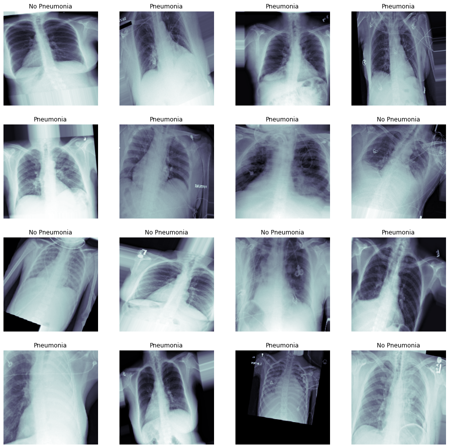

```python
## May want to look at some examples of our augmented training data.
## This is helpful for understanding the extent to which data is being manipulated prior to training,
## and can be compared with how the raw data look prior to augmentation

t_x, t_y = next(train_gen)
fig, m_axs = plt.subplots(4, 4, figsize = (16, 16))
for (c_x, c_y, c_ax) in zip(t_x, t_y, m_axs.flatten()):
    c_ax.imshow(c_x[:,:,0], cmap = 'bone')
    if c_y == 1:
        c_ax.set_title('Pneumonia')
    else:
        c_ax.set_title('No Pneumonia')
    c_ax.axis('off')
```

## Build your model:

Recommendation here to use a pre-trained network downloaded from Keras for fine-tuning

```python
def load_pretrained_model(vargs):

    model = VGG16(include_top=True, weights='imagenet')
    transfer_layer = model.get_layer(vargs)
    vgg_model = Model(inputs = model.input,
                          outputs = transfer_layer.output)
    return vgg_model
```

```python
def build_my_model(vargs):

    # my_model = Sequential()
    # ....add your pre-trained model, and then whatever additional layers you think you might
    # want for fine-tuning (Flatteen, Dense, Dropout, etc.)
    # if you want to compile your model within this function, consider which layers of your pre-trained model,
    # you want to freeze before you compile
    # also make sure you set your optimizer, loss function, and metrics to monitor
    # Passed arguments
    vgg_model = vargs

    for layer in vgg_model.layers[0:17]:
        layer.trainable = False

    final_model = Sequential()
    final_model.add(vgg_model)
    final_model.add(Flatten())
    final_model.add(Dropout(0.3))

    final_model.add(Dense(1024))
    final_model.add(LeakyReLU(alpha=0.05))
    final_model.add(Dropout(0.3))

    final_model.add(Dense(512))
    final_model.add(LeakyReLU(alpha=0.05))
    final_model.add(Dropout(0.3))

    final_model.add(Dense(128))
    final_model.add(LeakyReLU(alpha=0.05))
    final_model.add(Dropout(0.3))

    final_model.add(Dense(1,  activation='sigmoid'))

    optimizer = Adam(lr=5e-4)
    loss = 'binary_crossentropy'
    metrics = ['binary_accuracy']
    final_model.compile(optimizer=optimizer, loss=loss, metrics=metrics)

    return final_model
## STAND-OUT Suggestion: choose another output layer besides just the last classification layer of your modele
## to output class activation maps to aid in clinical interpretation of your model's results
```

```python
## Below is some helper code that will allow you to add checkpoints to your model,
## This will save the 'best' version of your model by comparing it to previous epochs of training

## Note that you need to choose which metric to monitor for your model's 'best' performance if using this code.
## The 'patience' parameter is set to 10, meaning that your model will train for ten epochs without seeing
## improvement before quitting

weight_path="{}_my_model2.best.hdf5".format('xray_class')

checkpoint = ModelCheckpoint(weight_path,
                              monitor='val_loss',
                              verbose=1,
                              save_best_only=True,
                              mode= 'min',                 #for val_loss mode should be min
                              save_weights_only = True)

early = EarlyStopping(monitor= 'val_loss',
                      mode= 'min',
                      patience=10)

callbacks_list = [checkpoint, early]
```

### Start training!

```python
final_model = build_my_model(load_pretrained_model(vargs = 'block5_pool'))
```

```
Downloading data from https://github.com/fchollet/deep-learning-models/releases/download/v0.1/vgg16_weights_tf_dim_ordering_tf_kernels.h5
```

```python
## train your model

# Todo

# history = my_model.fit_generator(train_gen,
#                           validation_data = (valX, valY),
#                           epochs = ,
#                           callbacks = callbacks_list)
train = final_model.fit_generator(train_gen,
                          validation_data = (valX, valY),
                          epochs = 50,
                          callbacks = callbacks_list)
```

```
Epoch 00001: val_loss improved from inf to 0.68790, saving model to xray_class_my_model2.best.hdf5

Epoch 00002: val_loss improved from 0.68790 to 0.55948, saving model to xray_class_my_model2.best.hdf5

Epoch 00003: val_loss did not improve from 0.55948

Epoch 00004: val_loss did not improve from 0.55948

Epoch 00005: val_loss improved from 0.55948 to 0.47939, saving model to xray_class_my_model2.best.hdf5

Epoch 00006: val_loss did not improve from 0.47939

Epoch 00007: val_loss improved from 0.47939 to 0.40060, saving model to xray_class_my_model2.best.hdf5

Epoch 00008: val_loss did not improve from 0.40060

Epoch 00009: val_loss did not improve from 0.40060

Epoch 00010: val_loss did not improve from 0.40060

Epoch 00011: val_loss did not improve from 0.40060

Epoch 00012: val_loss did not improve from 0.40060

Epoch 00013: val_loss did not improve from 0.40060

Epoch 00014: val_loss did not improve from 0.40060

Epoch 00015: val_loss did not improve from 0.40060

Epoch 00016: val_loss did not improve from 0.40060

Epoch 00017: val_loss did not improve from 0.40060
```

##### After training for some time, look at the performance of your model by plotting some performance statistics:

Note, these figures will come in handy for your FDA documentation later in the project

```python
## After training, make some predictions to assess your model's overall performance
## Note that detecting pneumonia is hard even for trained expert radiologists,
## so there is no need to make the model perfect.
final_model.load_weights(weight_path)
pred_Y = final_model.predict(valX, batch_size = 32, verbose = True)
```

```python
%matplotlib inline
from sklearn.metrics import roc_curve, average_precision_score, f1_score
```

```python
def plot_roc_curve(fper, tper):
    #source: https://www.codespeedy.com/how-to-plot-roc-curve-using-sklearn-library-in-python/
    plt.plot(fper, tper, color='orange', label='ROC')
    plt.plot([0, 1], [0, 1], color='darkblue', linestyle='--')
    plt.xlabel('False Positive Rate')
    plt.ylabel('True Positive Rate')
    plt.title('Receiver Operating Characteristic (ROC) Curve')
    plt.legend()
    plt.show()

def plot_auc(t_y, p_y):

    ## Hint: can use scikit-learn's built in functions here like roc_curve
    fpr, tpr, thresholds = roc_curve(p_y, t_y)
    plot_roc_curve(fpr, tpr)

## what other performance statistics do you want to include here besides AUC?
def avg_prec_score(t_y, p_y):
    average_precision = average_precision_score(t_y, p_y)
    print('Average precision-recall score: {0:0.2f}'.format(
      average_precision))


def f1_score(t_y, p_y):
    f1_scr = f1_score(t_y, p_y)
    print('F1 Score: ', round(f1_scr, 2))


#Also consider plotting the history of your model training:
def plot_history(history):
    N = len(history.history["loss"])
    plt.style.use("ggplot")
    plt.figure()
    plt.plot(np.arange(0, N), history.history["loss"], label="train_loss")
    plt.plot(np.arange(0, N), history.history["val_loss"], label="val_loss")
    plt.plot(np.arange(0, N), history.history["binary_accuracy"], label="train_acc")
    plt.plot(np.arange(0, N), history.history["val_binary_accuracy"], label="val_acc")
    plt.title("Training Loss and Accuracy on Dataset")
    plt.xlabel("Epoch #")
    plt.ylabel("Loss/Accuracy")
    plt.legend(loc="lower left")
```

```python
pred = np.round(pred_Y, 0)
```

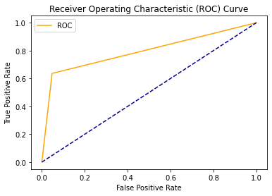

```
Average precision-recall score: 0.59
```

```python
## plot figures
plot_auc(valY, pred)

avg_prec_score(valY, pred)
```

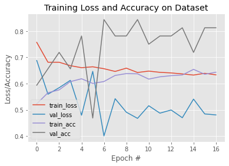

```python
plt.figure(figsize=(16,6))
plot_history(train)
```

Once you feel you are done training, you'll need to decide the proper classification threshold that optimizes your model's performance for a given metric (e.g. accuracy, F1, precision, etc. You decide)

```python
pred_label, true_label = [], []

for i in range(len(val_gen)):
    valX, valY = val_gen.next()
    pred_Y = final_model.predict(valX, batch_size = 32, verbose = True)
    true_label.extend([i for i in valY])
    pred_label.extend([i for i in pred_Y.squeeze()])
```

```python
def calculate_scores(y_true, y_pred):
    precision = precision_score(y_true, y_pred, average='binary')
    recall = recall_score(y_true, y_pred, average='binary')
    f1 = f1_score(y_true, y_pred, average='binary')

    return precision, recall, f1
```

```python
from sklearn.metrics import precision_score, recall_score, f1_score, accuracy_score

for i in np.arange(0.0, 1.0, 0.05):
    print("Threshold :  %.2f" % i)
    new_pred = [1.0 if x > i else 0.0 for x in pred_label]

    prec, recall, f1 = calculate_scores(true_label, new_pred)
    print('Precision: %.3f' % prec)
    print('Recall: %.3f' % recall)
    print('F1 Score: %.3f' % f1)

    print()
```

```
Threshold :  0.00
Precision: 0.198
Recall: 1.000
F1 Score: 0.330

Threshold :  0.05
Precision: 0.210
Recall: 0.951
F1 Score: 0.344

Threshold :  0.10
Precision: 0.223
Recall: 0.873
F1 Score: 0.355

Threshold :  0.15
Precision: 0.241
Recall: 0.834
F1 Score: 0.374

Threshold :  0.20
Precision: 0.251
Recall: 0.784
F1 Score: 0.380

Threshold :  0.25
Precision: 0.268
Recall: 0.728
F1 Score: 0.391

Threshold :  0.30
Precision: 0.273
Recall: 0.654
F1 Score: 0.385

Threshold :  0.35
Precision: 0.275
Recall: 0.576
F1 Score: 0.372

```

[output cut: 44 more lines]

```

Threshold :  0.85
Precision: 0.000
Recall: 0.000
F1 Score: 0.000

Threshold :  0.90
Precision: 0.000
Recall: 0.000
F1 Score: 0.000

Threshold :  0.95
Precision: 0.000
Recall: 0.000
F1 Score: 0.000
```

## Find the threshold that optimize your model's performance,

use that threshold to make binary classification. Make sure you take all your metrics into consideration.

We found that the best performing threshold value is 0.25:

```
Threshold :  0.25
Precision: 0.268
Recall: 0.728
F1 Score: 0.391
```

The F1 Score is a combination of both recall and precision, so I have giving primary preference to it. Although this blogpost [link](https://machinelearningmastery.com/precision-recall-and-f-measure-for-imbalanced-classification/) mentions that we should keep an eye on recall score for imbalanced datasets.

```python
new_pred = [1.0 if x > 0.25 else 0.0 for x in pred_label]
prec, recall, f1 = calculate_scores(true_label, new_pred)
print('Precision: %.3f' % prec)
print('Recall: %.3f' % recall)
print('F1 Score: %.3f' % f1)
```

```
Precision: 0.268
Recall: 0.728
F1 Score: 0.391
```

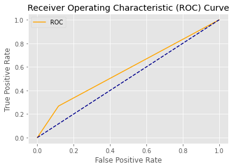

```
Average precision-recall score: 0.25
```

```python
## plot figures
plot_auc(true_label, new_pred)

avg_prec_score(true_label, new_pred)
```

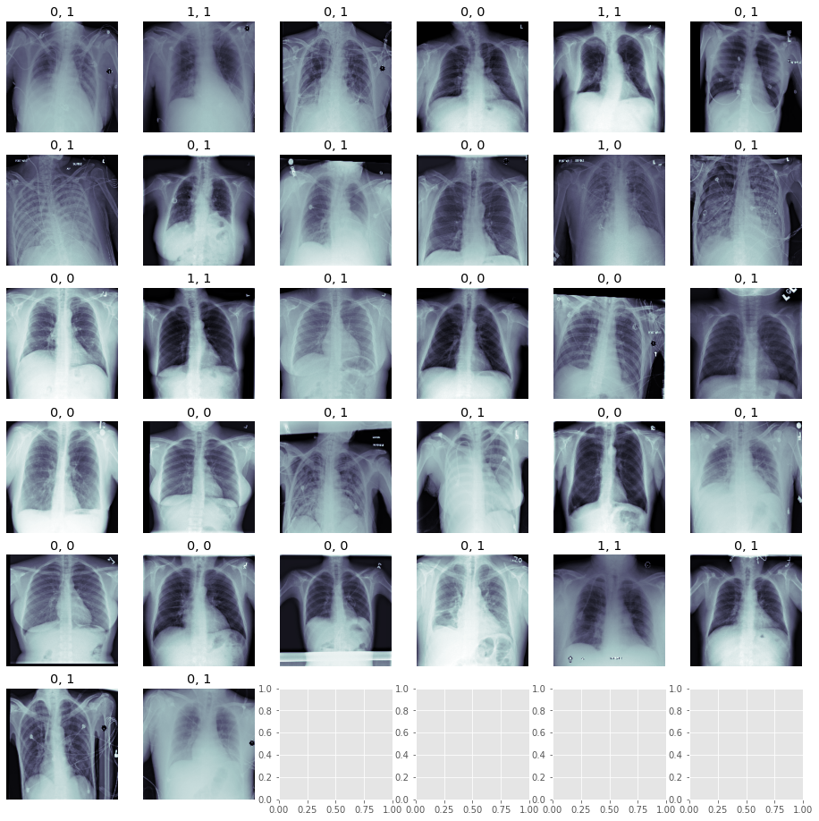

```python
## Let's look at some examples of predicted v. true with our best model:

# Todo

fig, m_axs = plt.subplots(6, 6, figsize = (16, 16))
i = 0
for (c_x, c_y, c_ax) in zip(valX[0:100], valY[0:100], m_axs.flatten()):
    c_ax.imshow(c_x[:,:,0], cmap = 'bone')
    if c_y == 1:
        if new_pred[i] > 0.25:
            c_ax.set_title('1, 1')
        else:
            c_ax.set_title('1, 0')
    else:
        if pred_Y[i] > 0.25:
            c_ax.set_title('0, 1')
        else:
            c_ax.set_title('0, 0')
    c_ax.axis('off')
    i=i+1
```

```python
## Just save model architecture to a .json:
model_json = final_model.to_json()
with open("my_model.json", "w") as json_file:
    json_file.write(model_json)
```